# Getting Started with FunCZIDM

Brody Erlandson

# 1 Introduction

In this vignette, we walk through how to use the `FunCZIDM` package and the shiny app. We use the case study data in the paper “A Bayesian Functional Concurrent Zero-Inflated Dirichlet-Multinomial Regression Model with Application to Infant Microbiome” to provide examples of how you would use and gain inference from the model. This package contains the data from the case study and the samples from the case study used in the paper, along with the scripts used to run the model and simulations. More details on reproducing the results in the paper can be found in the `README.md` file in the packages root directory.

# 2 Data Set Up

We can load the data from the case study using `data` function.

```r
library(FunCZIDM)

data(infantData)
```

This loads two objects: `infantCovariates` and `infantCounts`. The first step is to ensure the covariates and counts data are aligned. We can check that the two datasets are aligned by checking the subject id’s and times are aligned.

```r
# Check count and covariate data are aligned
(all(infantCounts$Subject == infantCovariates$Subject) &&
 all(infantCounts$Day.of.life.sample.obtained
     == infantCovariates$Day.of.life.sample.obtained))
```

```
## [1] TRUE
```

The `FunCZIDM` function requires the categorical covariates to be factors, and will use the reference level as the reference category for the variable. Below, we convert the categorical variables to factors and ensure the reference level matches that used in the case study of the main manuscript.

```r
# Convert the categorical variables to factors
infantCovariates$gender <- as.factor(infantCovariates$gender)
infantCovariates$mode.of.birth <- as.factor(infantCovariates$mode.of.birth)
infantCovariates$Room.category <- as.factor(infantCovariates$Room.category)
infantCovariates$milk <- as.factor(infantCovariates$milk)
infantCovariates$milk <- relevel(infantCovariates$milk, ref="< 10%")
infantCovariates$Period.of.study <- as.factor(infantCovariates$Period.of.study)
infantCovariates$Period.of.study <- relevel(infantCovariates$Period.of.study,
                                            ref="before")

# Check the types of the covariates
str(infantCovariates)
```

```
## 'data.frame':    922 obs. of  9 variables:
##  $ Subject                         : int  1 1 1 1 1 2 2 2 2 3 ...
##  $ Day.of.life.sample.obtained     : num  54.1 56 59.1 60 67.5 ...
##  $ Gestational.age.at.birth...weeks: num  26 26 26 26 26 26 26 26 26 25 ...
##  $ gender                          : Factor w/ 2 levels "female","male": 1 1 1 1 1 1 1 1 1 1 ...
##  $ mode.of.birth                   : Factor w/ 2 levels "caesarian section",..: 1 1 1 1 1 1 1 1 1 1 ...
##  $ Period.of.study                 : Factor w/ 2 levels "before","after": 1 1 1 1 1 1 1 1 1 1 ...
##  $ Room.category                   : Factor w/ 2 levels "Single ","open": 2 2 2 2 2 2 2 2 2 2 ...
##  $ milk                            : Factor w/ 3 levels "< 10%","10–50%",..: 1 1 1 1 1 1 1 1 1 1 ...
##  $ Proportion.days.on.antibiotics  : num  0.314 0.304 0.288 0.283 0.252 ...
```

The continuous variables will be standardized automatically, and the output of `FunCZIDM` will contain the means and standard deviations used for standardization. Other functions in this package will use this to standardize automatically, so you will always input the original scale and location of the continuous variables.

Now we can remove the subject id’s and time variables from the covariates and counts data. The `FunCZIDM` function will use the subject id’s and time variables as the `ids` and `varyingCov` arguments, respectively. Lastly, the package requires the counts data to be a matrix.

```r
# getting the index of the subject id's and the time-varying variable
idIdx <- which(colnames(infantCovariates) == "Subject")
timeIdx <- which(colnames(infantCovariates) == "Day.of.life.sample.obtained")
# extracting the subject ids and tv variable
ids <- infantCovariates[, idIdx]
time <- infantCovariates[, timeIdx]
infantCovariates <- infantCovariates[, -c(idIdx, timeIdx), drop = FALSE]

idIdx <- which(colnames(infantCounts) == "Subject")
timeIdx <- which(colnames(infantCounts) == "Day.of.life.sample.obtained")
infantCounts <- infantCounts[, -c(idIdx, timeIdx), drop = FALSE]
infantCounts <- as.matrix(infantCounts)
```

Now we can double check the data are set up correctly. Note the counts data must be a matrix, and the covariates data frame should only contain the covariates.

```r
str(infantCovariates)
```

```
## 'data.frame':    922 obs. of  7 variables:
##  $ Gestational.age.at.birth...weeks: num  26 26 26 26 26 26 26 26 26 25 ...
##  $ gender                          : Factor w/ 2 levels "female","male": 1 1 1 1 1 1 1 1 1 1 ...
##  $ mode.of.birth                   : Factor w/ 2 levels "caesarian section",..: 1 1 1 1 1 1 1 1 1 1 ...
##  $ Period.of.study                 : Factor w/ 2 levels "before","after": 1 1 1 1 1 1 1 1 1 1 ...
##  $ Room.category                   : Factor w/ 2 levels "Single ","open": 2 2 2 2 2 2 2 2 2 2 ...
##  $ milk                            : Factor w/ 3 levels "< 10%","10–50%",..: 1 1 1 1 1 1 1 1 1 1 ...
##  $ Proportion.days.on.antibiotics  : num  0.314 0.304 0.288 0.283 0.252 ...
```

```r
is.matrix(infantCounts)
```

```
## [1] TRUE
```

```r
colnames(infantCounts)
```

```
##  [1] "Actinobacteria"        "Alphaproteobacteria"   "Bacilli"
##  [4] "Bacteroidia"           "Betaproteobacteria"    "Clostridia"
##  [7] "Cyanobacteria"         "Epsilonproteobacteria" "Erysipelotrichi"
## [10] "Flavobacteria"         "Fusobacteria"          "Gammaproteobacteria"
## [13] "Sphingobacteria"       "Deltaproteobacteria"   "OD1_no_class"
## [16] "unclassified"
```

The `infantCounts` data contains the counts of the class level using 16S rRNA genes from infant stool samples.

# 3 Running the Model

Once the data are set up, one can sample from the FunC-ZIDM model using the `FunCZIDM` function. The first four inputs are what we prepared in the previous section. Next, we specify the number of total iterations (`iter`), the burn-in iterations (`burnIn`), and how much to thin by (`thin`). For demonstration purposes, we only do 85 iterations with a 75 burn-in while thinning to every 10th iteration. To assess convergence, you can return the burn-in samples by setting `returnBurnIn=TRUE`.

By default, the function will return the $\beta_{jpd}^*$ samples, $r_{jp}$ means, the acceptance rates for the $\beta_{jpd}^*$ and $r_{jp}$ after burn-in, and the average level of zero-inflation. One can specify other parameters to be returned using the `toReturn` argument. Commonly, one may want the relative abundance samples for each individual. This can be specified by adding `"RA"` to the `toReturn` argument.

The model has several priors that can be adjusted using the `priors` argument. Additionally, the proposal standard deviations for the $\beta_{jpd}^*$ and $r_{jp}$ can be initialized using the `proposalVars` argument. By default, the priors and proposal standard deviations are set to the values used in the case study and simulations of the paper.

For the splines, one can specify the degrees of freedom (`df`), the degree of the splines (`degree`), and the basis function to use (`basisFunc`). The default values (4, 3, and `splines::bs`) are the ones used in the case study and simulations of the paper.

If there are covariates that are assumed to not have a time-varying effect, one can specify the indices of these covariates in the `covWithoutVC` argument. In the case study, we assume the period of study to be time-invariant. By default, all covariates have a time-varying effect.

Lastly, one can save the output to a file using the `saveToFile` argument. If `TRUE`, the output will be saved to a file with the name specified by `fileName` or “output.rds” by default. This is useful when running multiple chains in order to combine them after all chains have finished running. One can also save a csv file indicating the proportion of mean $\beta_{jp}(t)$ functions that have the null function in the 95% credible interval using the `saveNullInBetaCI` argument. This saves to a file named “nullInBetaCI.csv” by default. This can be useful to see which covariates may have meaningful effects, specifically when there are a large number of covariates and/or categories. It is important to note that if the output contains the burn-in, then the mean $\beta_{jp}(t)$ will be estimated using the burn-in samples as well.

There are some other inputs that can be specified, however we recommend keeping them at their defaults unless a strong reason to change. A full description of the arguments and options can be found in the reference manual.

```r
output <- FunCZIDM(counts=infantCounts,
                   covariates=infantCovariates,
                   ids=ids,
                   varyingCov=time,
                   iter=85,
                   burnIn=75,
                   thin=10,
                   returnBurnIn=FALSE,
                   toReturn=c("RA"),
                   priors=list("first beta sd"=1, "a"=3, "b"=3, "alpha"=.01,
                               "beta"=10, "kappaShape"=100, "kappaRate"=900),
                   covWithoutVC=c(which(grepl("Period", colnames(infantCovariates)))),
                   saveToFile=FALSE,
                   saveNullInBetaCI=FALSE)
```

```
## [==>                                               ] 5% - 5/85 iterations[=====>                                            ] 11% - 10/85 iterations[========>                                         ] 17% - 15/85 iterations[===========>                                      ] 23% - 20/85 iteration…
## [1] "Total time taken: 1.221 seconds"
```

If multiple chains are run, one can combine the output files with the `combineOutputs` function. An example is provided below.

```r
outputFiles <- c("output1.rds", "output2.rds", "output3.rds", "output4.rds")
combinedOutput <- combineOutputs(outputFiles, saveToFile=FALSE)
```

If the output files contain the burn-in, then the combined output will too. One can resave the `rds` without the burn-in or take the last `(iter - burnIn)/thin` times the number of chains samples from the combined output. An example of resaving the output without the burn-in are provided below.

```r
files <- c("output1.rds", "output2.rds", "output3.rds", "output4.rds")
for (file in files) {
  output <- readRDS(file)
  output$beta <- output$beta[,, 7501:8500] # only keeping samples after burn-in
  saveRDS(output, file=file, compress="xz")
}
```

The package includes the combined output from the case study in the paper under `inst/extdata`, so it is not necessary to run the sampling. We will use this output for the inference section. We load the combined output below.

```r
combinedOutput <- readRDS(system.file("extdata", "plotCaseStudySamples.rds",
                          package = "FunCZIDM"))
names(combinedOutput)
```

```
##  [1] "interiorKnots"     "boundaryKnots"     "varyingCov"
##  [4] "colMapping"        "XvartoXColMapping" "basisFunc"
##  [7] "df"                "catNames"          "centerScaleList"
## [10] "basisCenters"      "beta"              "betaAcceptProp"
## [13] "rAcceptProp"       "rMeans"            "etaMeanPropZeros"
## [16] "RA"
```

The output object contains the samples and other information used in the other functions in the package. Most of these variables are not needed for direct use by the user, but are used in the other functions. One can read the description of each variable in the reference manual.

# 4 Inference

We demonstrate how to use the functions to obtain inference from the samples using the preloaded samples. The package can calculate the relative abundance $(\text{RA}_j(t))$ and $\alpha$-diversity functions $(\alpha(t))$, the multiplicative difference in relative abundance $(\Delta_v \text{RA}_{jp}(t))$ and $\alpha$-diversity functions $(\Delta_v \alpha_p(t))$, and the functional coefficients $(\beta_{jp}(t))$.

We begin by looking at the proportion of the credible interval of $\beta_{jp}(t)$ that contains the null function. By identifying the lowest proportions, we can narrow down which covariates and categories to investigate further, allowing for easier exploration of the $\alpha$-diversity and relative abundance.

```r
propNullInCI <- getPropNullInCI(combinedOutput,
                                varCovRange=c(0, 50)) # look at first 50 days
covToFocusOn <- c("gestational", "milk")
propNullInCI <- propNullInCI[grep(paste(covToFocusOn, collapse="|"),
                                  propNullInCI[,2], ignore.case=T), ]
head(propNullInCI[order(propNullInCI[,3]), ])
```

```
##      category              covariate
## [1,] "Bacilli"             "milk> 50%"
## [2,] "Bacilli"             "Gestational.age.at.birth...weeks"
## [3,] "Gammaproteobacteria" "Gestational.age.at.birth...weeks"
## [4,] "Clostridia"          "milk10–50%"
## [5,] "Gammaproteobacteria" "milk10–50%"
## [6,] "Actinobacteria"      "Gestational.age.at.birth...weeks"
##      Proportion 0 in 95 CI
## [1,] "0.36"
## [2,] "0.64"
## [3,] "0.668"
## [4,] "0.696"
## [5,] "0.996"
## [6,] "1"
```

## 4.1 Relative Abundance

The relative abundance and multiplicative difference in relative abundance can be calculated using the `calcRA` and `calcDeltaRA` functions, respectively. First, we need to note the index of each covariate in the model:

```r
combinedOutput$colMapping
```

```
## [[1]]
## [1] "(Intercept)"
##
## [[2]]
## [1] "Gestational.age.at.birth...weeks"
##
## [[3]]
## [1] "gendermale"
##
## [[4]]
## [1] "mode.of.birthvaginal delivery"
##
## [[5]]
## [1] "Period.of.studyafter"
##
## [[6]]
## [1] "Room.categorySingle "
##
## [[7]]
## [1] "milk> 50%"
##
## [[8]]
## [1] "milk10–50%"
##
## [[9]]
## [1] "Proportion.days.on.antibiotics"
```

These will be used for filling in the covariate profile and indicating which covariate you want the change in. Similarly, you can view the category names in the order the model uses them with `combinedOutput$catNames`. We fill the covariate profile with the intercept, 27 weeks of gestational age, the base categories, and .3 proportion of days on antibiotics. Then we use this, along with the output from `FunCZIDM`, to get the relative abundance from `calcRA`.

```r
# always put 1 for the intercept
covProfile <- c(1, 27, 0, 0, 0, 0, 0, 0, .3)
# calculate the relative abundance
RA <- calcRA(combinedOutput, covProfile=covProfile)
dim(RA)
```

```
## [1]  250   16 4000
```

We get all the categories relative abundance samples, where we have 250 timepoints, 16 categories, and 4000 samples. With these samples, we can visualize the mean relative abundance over time for the taxa. Below, we provide an example of plotting the mean relative abundance over time for Bacilli, Clostridia, and Gammaproteobacteria.

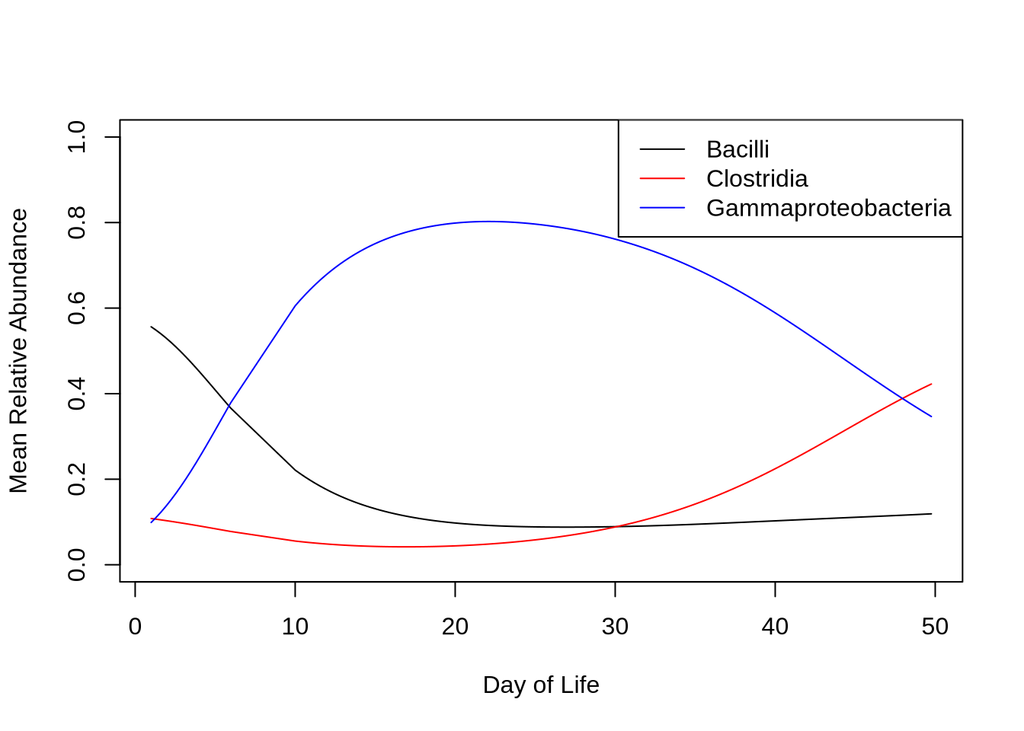

```r
taxa <- c("Bacilli", "Clostridia", "Gammaproteobacteria")
times <- rownames(RA) <= 50
RAMeans <- apply(RA[times, taxa, ], c(1, 2), mean)
x <- rownames(RAMeans)
plot(x, RAMeans[, taxa[1]], ylim=c(0, 1), type="l",
     ylab="Mean Relative Abundance",
     xlab="Day of Life")
lines(x, RAMeans[, taxa[2]], col="red")
lines(x, RAMeans[, taxa[3]], col="blue")
legend("topright", taxa, col=c("black", "red", "blue"), lty=1)
```

We can also view the distribution of the relative abundance at a particular time. We choose the 77th index, which is around day 25 of life.

```r
print(paste("Time point", rownames(RA)[77]))
```

```
## [1] "Time point 24.6027309236948"
```

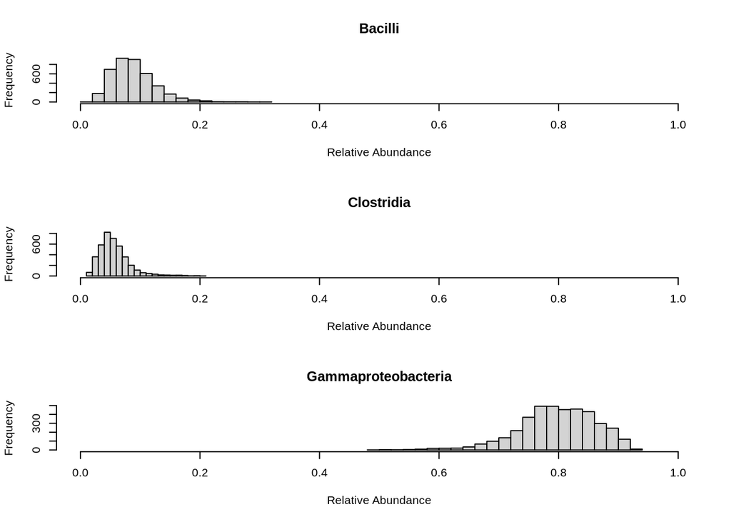

```r
par(mfrow=c(3, 1))
hist(RA[77, taxa[1], ], main=taxa[1], xlab="Relative Abundance",
     xlim=c(0, 1), breaks=20)
hist(RA[77, taxa[2], ], main=taxa[2], xlab="Relative Abundance",
     xlim=c(0, 1), breaks=20)
hist(RA[77, taxa[3], ], main=taxa[3], xlab="Relative Abundance",
     xlim=c(0, 1), breaks=20)
```

With `ggtern`, we can view the distribution on the simplex. To plot it on a 2-simplex, we must collapse some categories to have 3 categories total. Below we have the simplex of Bacilli, Gammaproteobacteria, and the sum of all other relative abundances. We then plot the distribution of these three on the simplex at three different time points. This gives us an idea of how the distribution shifts over time.

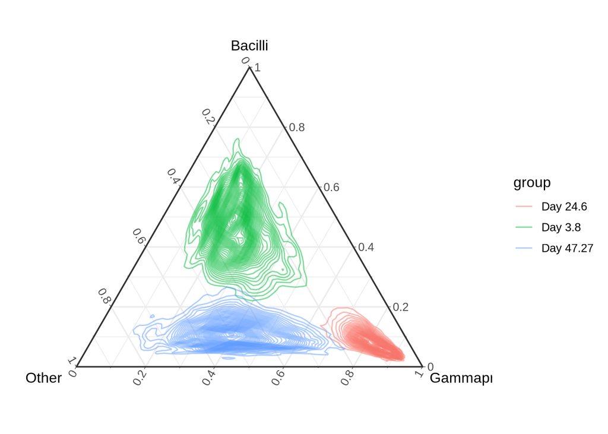

```r
# Getting the data at 3 different times and combining
S10 <- as.data.frame(t(RA[10,,])) # RA samples around day 4
# sum of each sample's RA other than Bacilli and Gammaproteobacteria
S10["Other"] <- 1 - rowSums(S10[c("Bacilli", "Gammaproteobacteria")])
S77 <- as.data.frame(t(RA[77,,])) # RA samples around day 25
S77["Other"] <- 1 - rowSums(S77[c("Bacilli", "Gammaproteobacteria")])
S150 <- as.data.frame(t(RA[150,,])) # RA samples around day 47
S150["Other"] <- 1 - rowSums(S150[c("Bacilli", "Gammaproteobacteria")])
# getting the group labels
S10$group <- paste("Day", round(as.numeric(rownames(RA)[10]), 2))
S77$group <- paste("Day", round(as.numeric(rownames(RA)[77]), 2))
S150$group <- paste("Day", round(as.numeric(rownames(RA)[150]), 2))
S <- rbind(S10, S77, S150)

ggtern(S, aes(Other, Bacilli, Gammaproteobacteria, color = group)) +
  stat_density_tern(
    aes(fill = after_stat(level)),
    geom = "path", bins = 50,  alpha = 0.5
  ) +
  scale_T_continuous(labels = seq(0, 1, 0.2), limits = c(0,1)) +
  scale_L_continuous(labels = seq(0, 1, 0.2), limits = c(0,1)) +
  scale_R_continuous(labels = seq(0, 1, 0.2), limits = c(0,1)) +
  theme_bw()
```

Now that we have an idea of the relative abundance at baseline, we can look into the multiplicative difference from these relative abundances. Using the same `covProfile` as before, we assign the covariates we want to see a change in (`forCovs`) and the change of the covariates respectively (`change`). Then, we assign categories that we want to the change in (`forCats`).

```r
covProfile <- c(1, 27, 0, 0, 0, 0, 0, 0, .3)
forCovs <- c(2, 7) # GA is 2nd idx and >50% BM in diet is 7th idx
change <- c(2, 1) # two week increase in gestational age and a 1 for indicating
                  # the change from <10% to >50% breast milk in the diet

forCats <- match(c("Bacilli", "Clostridia", "Gammaproteobacteria"),
                 combinedOutput$catNames) # gets the idx of these taxa
deltaRA <- calcDeltaRA(combinedOutput, change, forCovs, covProfile=covProfile,
                       forCats=forCats)
names(deltaRA)
```

```
## [1] "Gestational.age.at.birth...weeks" "milk> 50%"
```

```r
colnames(deltaRA[[1]]) # GA is 1
```

```
## [1] "Bacilli"             "Clostridia"          "Gammaproteobacteria"
```

```r
dim(deltaRA[[1]])
```

```
## [1]  250    3 4000
```

We can see the two covariates specified in the List, and for each covariate we have an array with the categories as the columns. The array has 250 timepoints, 3 categories, and 4000 samples. We can visualize the mean multiplicative change over time for the taxa we looked at before for the gestational age covariate below.

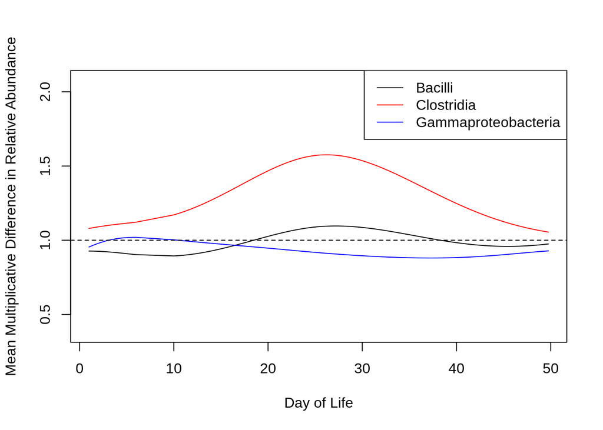

```r
taxa <- c("Bacilli", "Clostridia", "Gammaproteobacteria")
times <- rownames(deltaRA[[1]]) <= 50
deltaRAMeans <- apply(deltaRA[[1]][times,,], c(1, 2), mean)
x <- rownames(deltaRAMeans)
ylim <- c(min(deltaRAMeans) - 0.5, max(deltaRAMeans) + 0.5)

plot(x, deltaRAMeans[, taxa[1]], ylim=ylim, type="l",
     ylab="Mean Multiplicative Difference in Relative Abundance",
     xlab="Day of Life")
lines(x, deltaRAMeans[, taxa[2]], col="red")
lines(x, deltaRAMeans[, taxa[3]], col="blue")
abline(h=1, lty=2)
legend("topright", taxa, col=c("black", "red", "blue"), lty=1)
```

Additionally, we can find the distribution of the multiplicative difference at a particular time.

```r
print(paste("Time point", rownames(deltaRA[[1]])[77]))
```

```
## [1] "Time point 24.6027309236948"
```

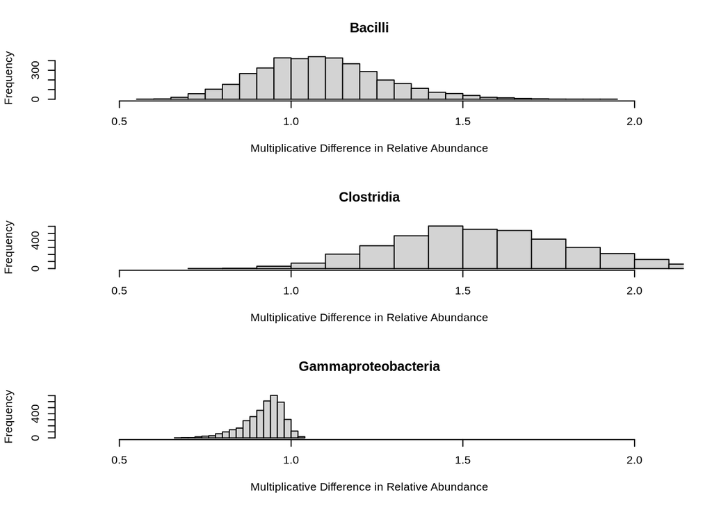

```r
par(mfrow=c(3, 1))
hist(deltaRA[[1]][77, taxa[1], ], main=taxa[1],
     xlab="Multiplicative Difference in Relative Abundance",
     xlim=ylim, breaks=20)
hist(deltaRA[[1]][77, taxa[2], ], main=taxa[2],
     xlab="Multiplicative Difference in Relative Abundance",
     xlim=ylim, breaks=20)
hist(deltaRA[[1]][77, taxa[3], ], main=taxa[3],
     xlab="Multiplicative Difference in Relative Abundance",
     xlim=ylim, breaks=20)
```

One may want to see what proportion of the multiplicative difference credible interval contains the null effect. This can be done using the samples to estimate the credible interval. By leaving `forCats` NULL, we get all the categories multiplicative difference.

```r
# calculate the change in relative abundance for all cats
change <- c(2) # two week increase in gestational age
forCovs <- c(2) # GA is 2nd idx

deltaRA <- calcDeltaRA(combinedOutput, change, forCovs, covProfile=covProfile)

lowerCI <- apply(deltaRA[[1]][times,,], c(1, 2), quantile, probs=c(.025))
upperCI <- apply(deltaRA[[1]][times,,], c(1, 2), quantile, probs=c(.975))

oneInCI <- (lowerCI <= 1)*(upperCI >= 1) # Null effect is 1
colMeans(oneInCI)
```

```
##        Actinobacteria   Alphaproteobacteria               Bacilli
##             1.0000000             0.7808219             1.0000000
##           Bacteroidia    Betaproteobacteria            Clostridia
##             0.6438356             0.8356164             0.6506849
##         Cyanobacteria Epsilonproteobacteria       Erysipelotrichi
##             0.6712329             0.6575342             0.6712329
##         Flavobacteria          Fusobacteria   Gammaproteobacteria
##             0.7328767             0.6849315             0.8287671
##       Sphingobacteria   Deltaproteobacteria          OD1_no_class
##             0.6643836             0.6643836             0.6643836
##          unclassified
##             0.6849315
```

Now we can look at the change of the simplex distribution of Gammaproteobacteria, Clostridia, and the sum of the others when changing gestational age.

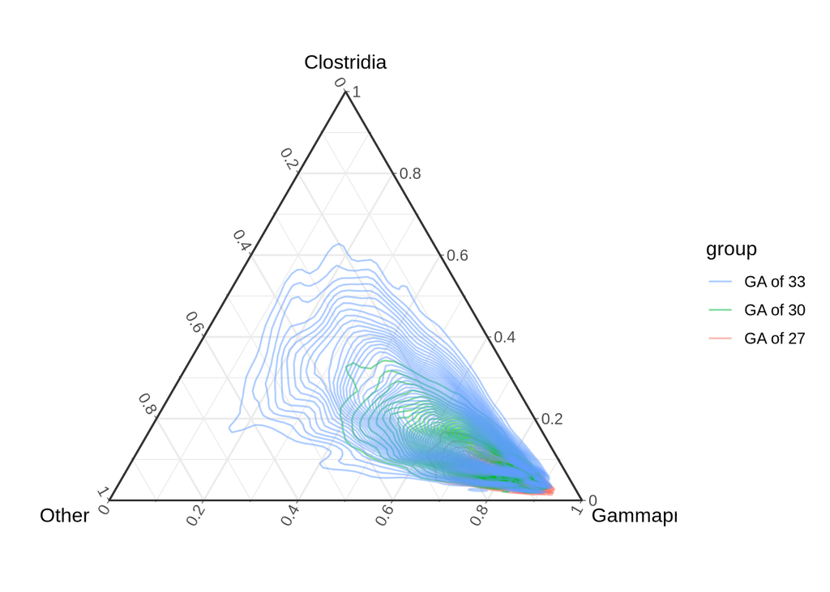

```r
# Getting the data at 3 different GA and combining
covProfile <- c(1, 27, 0, 0, 0, 0, 0, 0, .3)
RA <- calcRA(combinedOutput, covProfile=covProfile)
S27 <- as.data.frame(t(RA[85,,]))
S27["Other"] <- 1 - rowSums(S27[c("Clostridia", "Gammaproteobacteria")])
covProfile <- c(1, 30, 0, 0, 0, 0, 0, 0, .3)
RA <- calcRA(combinedOutput, covProfile=covProfile)
S30 <- as.data.frame(t(RA[85,,]))
S30["Other"] <- 1 - rowSums(S30[c("Clostridia", "Gammaproteobacteria")])
covProfile <- c(1, 33, 0, 0, 0, 0, 0, 0, .3)
RA <- calcRA(combinedOutput, covProfile=covProfile)
S33 <- as.data.frame(t(RA[85,,]))
S33["Other"] <- 1 - rowSums(S33[c("Clostridia", "Gammaproteobacteria")])
S27$group <- paste("GA of", 27)
S30$group <- paste("GA of", 30)
S33$group <- paste("GA of", 33)
cols <- c("Clostridia", "Gammaproteobacteria", "Other", "group")
S <- rbind(S27[,cols], S30[,cols], S33[,cols])

ggtern(S, aes(Other, Clostridia, Gammaproteobacteria, color = group)) +
  stat_density_tern(
    aes(fill = after_stat(level)),
    geom = "path", bins = 50, alpha = 0.5
  ) +
  scale_T_continuous(labels = seq(0, 1, 0.2), limits = c(0,1)) +
  scale_L_continuous(labels = seq(0, 1, 0.2), limits = c(0,1)) +
  scale_R_continuous(labels = seq(0, 1, 0.2), limits = c(0,1)) +
  theme_bw() +
  guides(color = guide_legend(reverse = TRUE))
```

## 4.2 $\alpha$-diversity

The functions to get the $\alpha$-diversity functions $(\alpha(t))$, the multiplicative difference in $\alpha$-diversity functions $(\Delta_v \alpha_p(t))$ work similarly to the relative abundance functions. Using the same covariate profile, we can find the diversity over time using `calcAlphaDiv`. We have one extra parameter to set than `calcRA`, `l`, that controls the weight given toward the smaller categories.

```r
covProfile <- c(1, 27, 0, 0, 0, 0, 0, 0, .3)
l <- 0.75 # Hill's diversity parameter
alphaDiv <- calcAlphaDiv(combinedOutput, l=l, covProfile=covProfile)
dim(alphaDiv)
```

```
## [1]  250 4000
```

The diversity uses all the categories, so we just have 250 timepoints and 4000 samples. Again, one can plot the mean change over time.

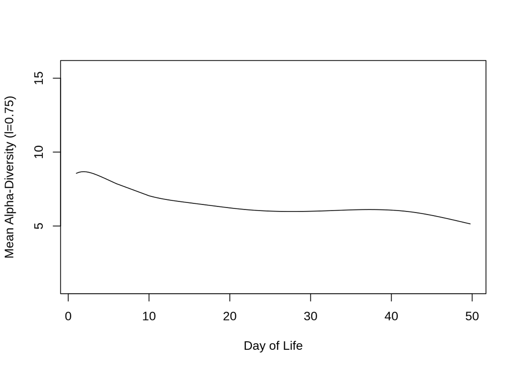

```r
times <- rownames(alphaDiv) <= 50
meanDiv <- rowMeans(alphaDiv[times,])
ylim <- c(min(alphaDiv), max(alphaDiv))
x <- rownames(alphaDiv[times,])

plot(x, meanDiv, ylim=ylim, type="l",
     ylab=paste0("Mean Alpha-Diversity (l=", l, ")"),
     xlab="Day of Life")
```

We can calculate the multiplicative difference from this $\alpha$-diversity function for a change in a covariate. We can calculate the mean change for all covariates, and find each covariates proportion of credible intervals that contain the null effect. The inputs are the same as `calcDeltaRA` with `l` parameter in addition.

```r
# calculate the change in relative abundance
change <- c(2, # two week increase in gestational age
            1, # indicating a change from female to male
            1, # indicating a change from c-section to vaginal delivery
            1, # indicating a change from before to after study change
            1, # indicating a change from multipatient room to single
            1, # indicating a change from <10% to >50% breast milk
            1, # indicating a change from <10% to 10-50% breast milk
            .3)# .3 increase in proportion of days on antibiotics
forCovs <- 2:9 # all covariates (not intercept)

deltaAlphaDiv <- calcDeltaAlphaDiv(combinedOutput, change, forCovs, l=l,
                                   covProfile=covProfile)
names(deltaAlphaDiv)
```

```
## [1] "Gestational.age.at.birth...weeks" "gendermale"
## [3] "mode.of.birthvaginal delivery"    "Period.of.studyafter"
## [5] "Room.categorySingle "             "milk> 50%"
## [7] "milk10–50%"                       "Proportion.days.on.antibiotics"
```

```r
dim(deltaAlphaDiv[[1]]) # 1 is GA
```

```
## [1]  250 4000
```

```r
times <- rownames(deltaAlphaDiv[[1]]) <= 50

# proportion in the credible interval across time
for (cov in 1:8) {
  CI <- apply(deltaAlphaDiv[[cov]][times,], 1, quantile, probs=c(.025, .975))
  oneInCI <- (CI[1,] <= 1)*(CI[2,] >= 1) # Null effect is 1
  print(paste0(combinedOutput$colMapping[[cov+1]], ": ", mean(oneInCI)))
}
```

```
## [1] "Gestational.age.at.birth...weeks: 0.684931506849315"
## [1] "gendermale: 0.63013698630137"
## [1] "mode.of.birthvaginal delivery: 1"
## [1] "Period.of.studyafter: 0.89041095890411"
## [1] "Room.categorySingle : 0.534246575342466"
## [1] "milk> 50%: 0.931506849315068"
## [1] "milk10–50%: 1"
## [1] "Proportion.days.on.antibiotics: 0.643835616438356"
```

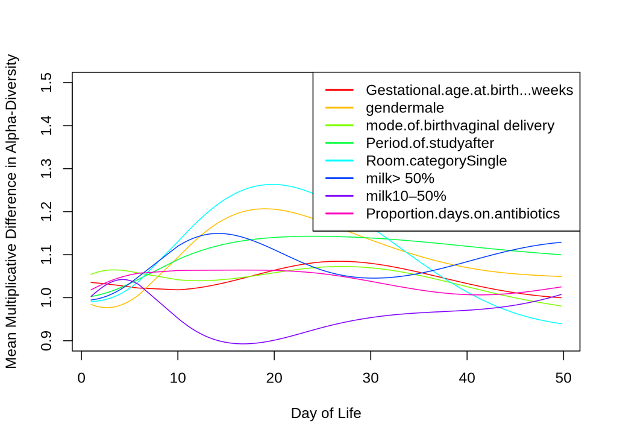

```r
# Mean across time
covname <- combinedOutput$colMapping[[2]]
x <- rownames(deltaAlphaDiv[[1]][times,])
cols <- rainbow(8)
meanDivFunc <- apply(deltaAlphaDiv[[1]][times,], 1, mean)
plot(x, meanDivFunc, type="l", col=cols[1], ylim=c(.9, 1.5),
     ylab="Mean Multiplicative Difference in Alpha-Diversity",
     xlab="Day of Life")
for (cov in 2:8) {
  meanDivFunc <- apply(deltaAlphaDiv[[cov]][times,], 1, mean)
  lines(x, meanDivFunc, col=cols[cov])
  covname <- c(covname, combinedOutput$colMapping[[cov+1]])
}
legend("topright", legend=covname, col=cols, lwd = 2)
```

Again, all categories are used in calculating the diversity, so we just have 250 timepoints and 4000 samples. We find that the mode of birth and the breast milk proportion are the only covariates that contain the null effect in the credible interval over all the first 50 days.

We can plot the simplex for a few different covariate profiles to see the distributional shifts. We will plot the simplex for Bacilli, Gammaproteobacteria, and the sum of the other categories.

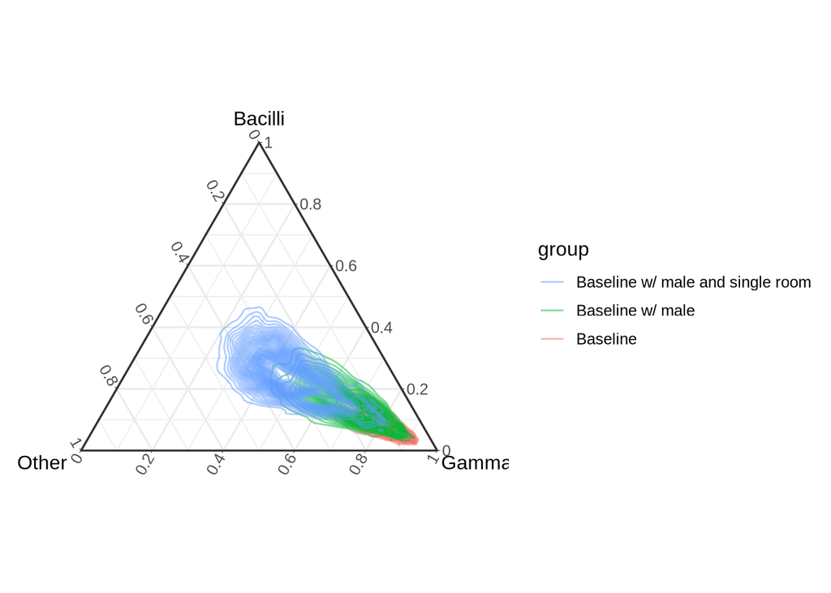

```r
# Getting the data at 3 different GA and combining
covProfile <- c(1, 27, 0, 0, 0, 0, 0, 0, .3) # baseline
RA <- calcRA(combinedOutput, covProfile=covProfile)
SB <- as.data.frame(t(RA[80,,]))
SB["Other"] <- 1 - rowSums(SB[c("Bacilli", "Gammaproteobacteria")])
covProfile <- c(1, 27, 1, 0, 0, 0, 0, 0, .3) # baseline w/ male
RA <- calcRA(combinedOutput, covProfile=covProfile)
SM <- as.data.frame(t(RA[80,,]))
SM["Other"] <- 1 - rowSums(SM[c("Bacilli", "Gammaproteobacteria")])
covProfile <- c(1, 27, 1, 0, 0, 1, 0, 0, .3) # baseline w/ male and single room
RA <- calcRA(combinedOutput, covProfile=covProfile)
SMS <- as.data.frame(t(RA[80,,]))
SMS["Other"] <- 1 - rowSums(SMS[c("Bacilli", "Gammaproteobacteria")])
SB$group <- "Baseline"
SM$group <- "Baseline w/ male"
SMS$group <- "Baseline w/ male and single room"
cols <- c("Bacilli", "Gammaproteobacteria", "Other", "group")
S <- rbind(SB[,cols], SM[,cols], SMS[,cols])

ggtern(S, aes(Other, Bacilli, Gammaproteobacteria, color = group)) +
  stat_density_tern(
    aes(fill = after_stat(level)),
    geom = "path", bins = 50, alpha = 0.5
  ) +
  scale_T_continuous(labels = seq(0, 1, 0.2), limits = c(0,1)) +
  scale_L_continuous(labels = seq(0, 1, 0.2), limits = c(0,1)) +
  scale_R_continuous(labels = seq(0, 1, 0.2), limits = c(0,1)) +
  theme_bw() +
  guides(color = guide_legend(reverse = TRUE))
```

## 4.3 $\beta_{cp}(t)$

At times, the functional covariate itself may be of interest. These are particularly useful for seeing which covariate is causing the estimated changes.

```r
betas <- getBetaFunctions(combinedOutput)
dim(betas)
```

```
## [1]  250   16 4000
```

This gives us the intercept for each category, and with `cov` you can specify which covariate you want. For example,

```r
betas <- getBetaFunctions(combinedOutput, cov=2)
dim(betas)
```

```
## [1]  250   16 4000
```

provides the gestational age $\beta_{jp}(t)$ samples for each category. We can rank the average mean $\beta_{jp}(t)$ over time, and rank the maximum mean $|\beta_{jp}(t)|$.

```r
times <- rownames(betas) <= 50
meanBetas <- apply(betas[times,,], c(1,2), mean)
# average mean B_jp(t)
sort(colMeans(meanBetas))
```

```
##   Gammaproteobacteria               Bacilli        Actinobacteria
##         -0.3230395646         -0.2500284054         -0.0793649641
##    Betaproteobacteria   Alphaproteobacteria         Flavobacteria
##         -0.0318526633         -0.0260968092         -0.0169873841
##         Cyanobacteria       Erysipelotrichi       Sphingobacteria
##         -0.0064117428         -0.0055841435         -0.0037832965
##          Fusobacteria   Deltaproteobacteria          OD1_no_class
##         -0.0029105130         -0.0023022204         -0.0019955905
##          unclassified Epsilonproteobacteria            Clostridia
##         -0.0006538167         -0.0003267063          0.0756626918
##           Bacteroidia
##          0.0939509978
```

```r
# max mean abs(B_jp(t))
sort(apply(abs(meanBetas), 2, max))
```

```
##          OD1_no_class   Deltaproteobacteria          unclassified
##           0.002650993           0.003520074           0.003649447
## Epsilonproteobacteria       Sphingobacteria          Fusobacteria
##           0.004580849           0.005098066           0.006108551
##       Erysipelotrichi         Cyanobacteria   Alphaproteobacteria
##           0.007659003           0.008247732           0.034991949
##         Flavobacteria    Betaproteobacteria           Bacteroidia
##           0.035132755           0.061122915           0.109437620
##            Clostridia        Actinobacteria               Bacilli
##           0.129053764           0.141229152           0.311853126
##   Gammaproteobacteria
##           0.522271018
```

This shows the coefficient of Gammaproteobacteria for gestational age has the largest negative average mean $\beta_{jp}(t)$ over time and the largest $|\beta_{jp}(t)|$. Most other coefficients are close to zero, so when the gestational age is changed the concentration parameter of Gammaproteobacteria is changed the most. Since the coefficient is negative, this causes the distribution to get pushed away from Gammaproteobacteria’s corner of the simplex, and raises all other relative abundance consequently.

# 5 Generating Datasets

We provide a function to easily generate a dataset if needed for testing or otherwise.

```r
set.seed(46623)
n <- 50 # Number of individuals
c <- 10 # Number of categories
p <- 10 # Number of functional covariates
totalCount <- c(150, 450)
generatedData <- generateData(n, c, p, totalCountRange=totalCount)
```

`generatedData` contains the generated data: counts, covariates, ids, timepoints and the true parameters. To recover the true function for each covariate, we use the following code:

```r
cov <- 1 # the first covariate, not the intercept.
cat <- 1
f <- generatedData$funcList[[round(generatedData$betaFuncMat[cov, cat])]]
plusMinus <- generatedData$betaFuncMat[cov, cat] - round(generatedData$betaFuncMat[cov, cat])
betaFunc <- ifelse(plusMinus >= 0, 1, -1)*f(generatedData$timePoints)
```

The intercept functions can be found in `generatedData$betaIntercepts`. An example of fitting the model with the generated data, then checking the coverage of the true beta functions are below.

```r
X <- generatedData[["covariates"]]
counts <- generatedData[["counts"]]
personID <- generatedData[["ids"]]
timePoints <- generatedData[["timePoints"]]

output <- FunCZIDM(counts, X, personID, timePoints, iter=4000, burnIn=2000,
                   thin=10, df=4, saveToFile=FALSE, saveNullInBetaCI = FALSE)
```

```
## [==>                                               ] 5% - 200/4000 iterations[=====>                                            ] 10% - 400/4000 iterations[=======>                                          ] 15% - 600/4000 iterations[==========>                                       ] 20% - 800/4…
## [1] "Total time taken: 14.78 seconds"
```

```r
betaEst <- getBetaFunctions(output, cov=2)[,1,] # first cov and cat
betaEstCI <- apply(betaEst, 1, quantile, probs=c(0.025, .975))

cov <- 1 # the first covariate, not the intercept.
cat <- 1
testpoints <- as.numeric(rownames(betaEst))
f <- generatedData$funcList[[round(generatedData$betaFuncMat[cov, cat])]]
plusMinus <- generatedData$betaFuncMat[cov, cat] -
             round(generatedData$betaFuncMat[cov, cat])
betaFunc <- ifelse(plusMinus >= 0, 1, -1)*f(testpoints)

betaPropInCI <- mean((betaFunc >= betaEstCI[1,])*(betaFunc <= betaEstCI[2,]))
print(betaPropInCI)
```

```
## [1] 1
```

We can plot the estimated mean and true $\beta_{jp}(t)$ below to assess estimation performance.

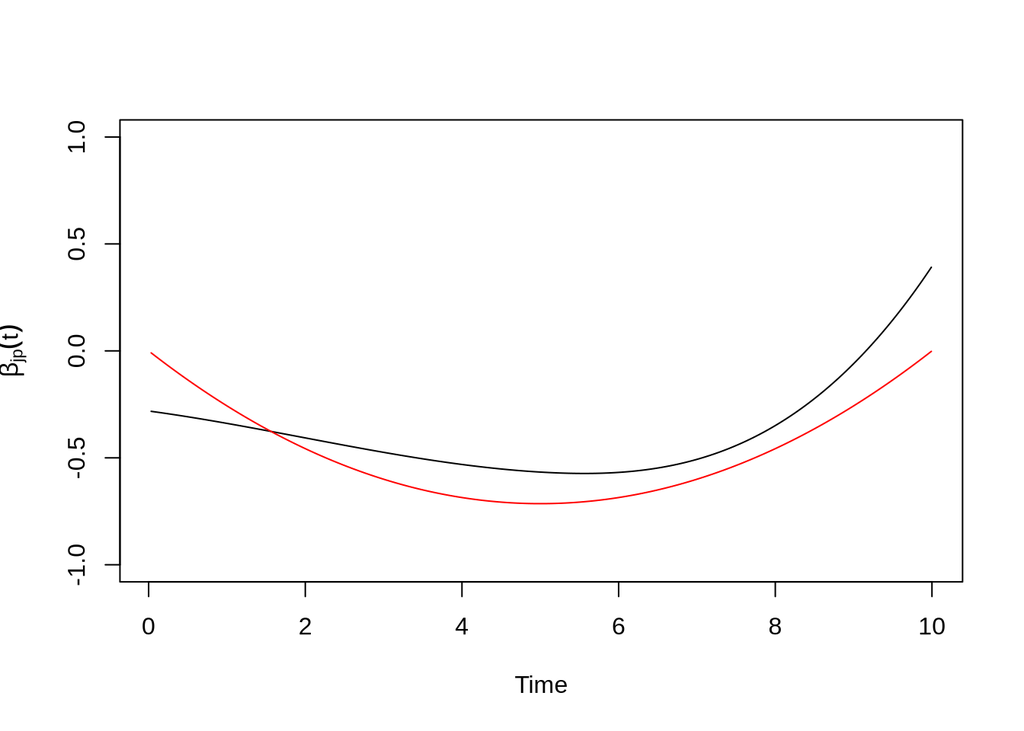

```r
plot(testpoints, rowMeans(betaEst), col="black", type="l", ylim=c(-1,1),
     ylab=expression(beta[jp](t)), xlab="Time")
lines(testpoints, betaFunc, col="red")
```

# 6 `shiny` App

For visualization, the `shinyApp` associated with the package can be used to generate plots with ease. This app can be run with `runPlotApp`, then the samples can be uploaded locally.

```r
runPlotApp(useCondaEnv=TRUE)
```

It is not necessary to create a conda environment, but it is recommended to avoid package issues. The `README` on the GitHub page contains instructions on how to set up the conda environment.

# 7 Conclusion

We walk through each function in the `FunCZIDM` package, however every input variable is not covered in this vignette. Many of these inputs are at recommended default values, and do not need to be changed unless there is a strong reason to do so. The reference manual contains all of the function parameters, so please refer to the reference for a further description of the functions.